# Titanic EDA

To get a sense for the Titanic data set, we are going to do some exploratory data analysis. As part of that, we will use the `xray` package to check for anomalies and look at distributions.

```r
library(tidyverse)
library(xray)
library(knitr)
```

## Data Import

First, we need to import the training and testing data.

```r
training <- read_csv("train.csv", progress = FALSE)
testing <- read_csv("test.csv", progress = FALSE)
```

Now, let’s take a look at the data.

```r
training
```

| PassengerId | Survived | Pclass | Name | Sex | Age | SibSp | Parch | Ticket | Fare | Cabin | Embarked |
| --- | --- | --- | --- | --- | --- | --- | --- | --- | --- | --- | --- |
| 1 | 0 | 3 | Braund, Mr. Owen Harris | male | 22.00 | 1 | 0 | A/5 21171 | 7.2500 | NA | S |
| 2 | 1 | 1 | Cumings, Mrs. John Bradley (Florence Briggs Thayer) | female | 38.00 | 1 | 0 | PC 17599 | 71.2833 | C85 | C |
| 3 | 1 | 3 | Heikkinen, Miss. Laina | female | 26.00 | 0 | 0 | STON/O2. 3101282 | 7.9250 | NA | S |
| 4 | 1 | 1 | Futrelle, Mrs. Jacques Heath (Lily May Peel) | female | 35.00 | 1 | 0 | 113803 | 53.1000 | C123 | S |
| 5 | 0 | 3 | Allen, Mr. William Henry | male | 35.00 | 0 | 0 | 373450 | 8.0500 | NA | S |
| 6 | 0 | 3 | Moran, Mr. James | male | NA | 0 | 0 | 330877 | 8.4583 | NA | Q |
| 7 | 0 | 1 | McCarthy, Mr. Timothy J | male | 54.00 | 0 | 0 | 17463 | 51.8625 | E46 | S |
| 8 | 0 | 3 | Palsson, Master. Gosta Leonard | male | 2.00 | 3 | 1 | 349909 | 21.0750 | NA | S |
| 9 | 1 | 3 | Johnson, Mrs. Oscar W (Elisabeth Vilhelmina Berg) | female | 27.00 | 0 | 2 | 347742 | 11.1333 | NA | S |
| 10 | 1 | 2 | Nasser, Mrs. Nicholas (Adele Achem) | female | 14.00 | 1 | 0 | 237736 | 30.0708 | NA | C |

[output cut: 881 more lines]

We can also use `glimpse` to take a look at the variables.

```r
glimpse(training)
```

```
Observations: 891
Variables: 12
$ PassengerId <int> 1, 2, 3, 4, 5, 6, 7, 8, 9, 10, 11, 12, 13, 14, 15, 16, 17, 18, 19, 20, 21...
$ Survived    <int> 0, 1, 1, 1, 0, 0, 0, 0, 1, 1, 1, 1, 0, 0, 0, 1, 0, 1, 0, 1, 0, 1, 1, 1, 0...
$ Pclass      <int> 3, 1, 3, 1, 3, 3, 1, 3, 3, 2, 3, 1, 3, 3, 3, 2, 3, 2, 3, 3, 2, 2, 3, 1, 3...
$ Name        <chr> "Braund, Mr. Owen Harris", "Cumings, Mrs. John Bradley (Florence Briggs T...
$ Sex         <chr> "male", "female", "female", "female", "male", "male", "male", "male", "fe...
$ Age         <dbl> 22, 38, 26, 35, 35, NA, 54, 2, 27, 14, 4, 58, 20, 39, 14, 55, 2, NA, 31, ...
$ SibSp       <int> 1, 1, 0, 1, 0, 0, 0, 3, 0, 1, 1, 0, 0, 1, 0, 0, 4, 0, 1, 0, 0, 0, 0, 0, 3...
$ Parch       <int> 0, 0, 0, 0, 0, 0, 0, 1, 2, 0, 1, 0, 0, 5, 0, 0, 1, 0, 0, 0, 0, 0, 0, 0, 1...
$ Ticket      <chr> "A/5 21171", "PC 17599", "STON/O2. 3101282", "113803", "373450", "330877"...
$ Fare        <dbl> 7.2500, 71.2833, 7.9250, 53.1000, 8.0500, 8.4583, 51.8625, 21.0750, 11.13...
$ Cabin       <chr> NA, "C85", NA, "C123", NA, NA, "E46", NA, NA, NA, "G6", "C103", NA, NA, N...
$ Embarked    <chr> "S", "C", "S", "S", "S", "Q", "S", "S", "S", "C", "S", "S", "S", "S", "S"...
```

We have 12 variables that we will want to look at. According to the data set description from Kaggle, the variables are defined in the following way:

- PassengerId – A numerical id for each passenger.
- Survived – The response variable as a factor showing survival.
- Pclass – The ticket class of the passenger used as a proxy for socio-economic class. This variable is a factor with levels 1 = 1st (Upper Class), 2 = 2nd (Middle Class), and 3 = 3rd (Lower Class).
- Name – The full name of the passenger with title. Married female passengers appear to have their partner’s name listed with their actual name in parentheses.
- Sex – A factor showing the sex of the passenger.
- Age – The age of the passenger. Estimated ages are given as xx.#.
- SibSp – The number of siblings and spouses the passnger has aboard.
- Parch – The number of parent/children relationships that the passneger has aboard.
- Ticket – Ticket number of the passenger.
- Fare – The passenger fare.
- Cabin – The passenge cabin number.
- Embarked – The port of embarkation. This is a factor with three levels C = Cherbourg, Q = Queenstown, S = Southampton.

Before we begin the exploration, let’s recode the factors with proper levels.

```r
training <- training %>%
  mutate(Survived = factor(Survived,
                           levels = c(1, 0),
                           labels = c("Yes", "No"))) %>%
  mutate(Pclass = factor(Pclass,
                         levels = c(3, 2, 1),
                         labels = c("3rd", "2nd", "1st"),
                         ordered = TRUE)) %>%
  mutate(Sex = factor(Sex,
                      levels = c("male", "female"))) %>%
  mutate(Embarked = factor(Embarked,
                           levels = c("C", "Q", "S"),
                           labels = c("Cherbourg", "Queenstown", "Southampton")))
```

```r
testing <- testing %>%
  mutate(Pclass = factor(Pclass,
                         levels = c(3, 2, 1),
                         labels = c("3rd", "2nd", "1st"),
                         ordered = TRUE)) %>%
  mutate(Sex = factor(Sex,
                      levels = c("male", "female"))) %>%
  mutate(Embarked = factor(Embarked,
                           levels = c("C", "Q", "S"),
                           labels = c("Cherbourg", "Queenstown", "Southampton")))
```

## Exploration with `xray`

### Checking Anomalies with `xray`

Now that the data sets have been re-coded with factors, let’s take a look for any anomalies in the data set using the `xray` package. The `xray` package gives access to several functions for performing exploratory data analysis. The first one we will use is the `anomalies()` function that returns a data frame summarizing the variables in a provided data frame.

The function returns summaries for each variable showing:

- The number of observations
- The number and percentage of observations that are NA
- The number and percentage of observations that are zero
- The number and percentage of observations that are blank
- The number and percentage of observations that are infinite
- The number of distinct observations
- The variable type
- The percentage of observations that are “anomalous”

This information can give us a starting point to examine the data set and see what variables will be useful for training our models.

```r
xray::anomalies(training)$variables %>%
  knitr::kable()
```

| Variable | q | qNA | pNA | qZero | pZero | qBlank | pBlank | qInf | pInf | qDistinct | type | anomalous_percent |
| --- | --- | --- | --- | --- | --- | --- | --- | --- | --- | --- | --- | --- |
| Cabin | 891 | 687 | 77.1% | 0 | - | 0 | - | 0 | - | 148 | Character | 77.1% |
| Parch | 891 | 0 | - | 678 | 76.09% | 0 | - | 0 | - | 7 | Integer | 76.09% |
| SibSp | 891 | 0 | - | 608 | 68.24% | 0 | - | 0 | - | 7 | Integer | 68.24% |
| Age | 891 | 177 | 19.87% | 0 | - | 0 | - | 0 | - | 89 | Numeric | 19.87% |
| Fare | 891 | 0 | - | 15 | 1.68% | 0 | - | 0 | - | 248 | Numeric | 1.68% |
| Embarked | 891 | 2 | 0.22% | 0 | - | 0 | - | 0 | - | 4 | Factor | 0.22% |
| Survived | 891 | 0 | - | 0 | - | 0 | - | 0 | - | 2 | Factor | - |
| Sex | 891 | 0 | - | 0 | - | 0 | - | 0 | - | 2 | Factor | - |
| Pclass | 891 | 0 | - | 0 | - | 0 | - | 0 | - | 3 | Unknown | - |
| Ticket | 891 | 0 | - | 0 | - | 0 | - | 0 | - | 681 | Character | - |
| PassengerId | 891 | 0 | - | 0 | - | 0 | - | 0 | - | 891 | Integer | - |
| Name | 891 | 0 | - | 0 | - | 0 | - | 0 | - | 891 | Character | - |

There are also three variables that show a number of zero observations. For the Parch and SibSp variables, this should be fine. This just means that those passengers are traveling without family members. For the fare, we may want to investigate which of the passengers have zero fare as they may be crew members or have some other identifying information.

One interesting point that pops out from the anomalies function is that the Ticket variable has only 681 distinct observations. This means that there must be a few repeat tickets that bears a quick investigation.

Note: As of this writing, the `xray` does not currently support ordered factors. This is why the `Pclass` variable has a class of “Unknown” from the anomalies() function. This will also cause a problem with the distributions() function so we will remove the ordering for that.

### Distributions with `xray`

For the bar plots, the axis labeled as “Rows” is actually the number of observations of each variable category. For the histograms, the number of observations has been scaled for the associated density plot.

| Variable | p_1 | p_10 | p_25 | p_50 | p_75 | p_90 | p_99 |
| --- | --- | --- | --- | --- | --- | --- | --- |
| Parch | 0 | 0 | 0 | 0 | 0 | 2 | 4 |
| SibSp | 0 | 0 | 0 | 0 | 1 | 1 | 5 |
| Age | 1 | 14 | 20.125 | 28 | 38 | 50 | 65.87 |
| Fare | 0 | 7.55 | 7.9104 | 14.4542 | 31 | 77.9583 | 249.0062 |

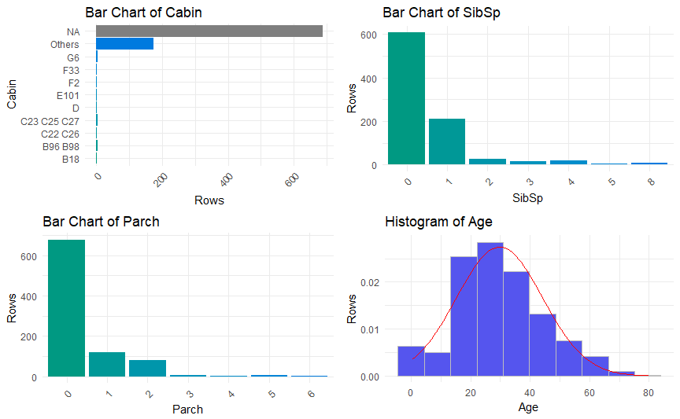

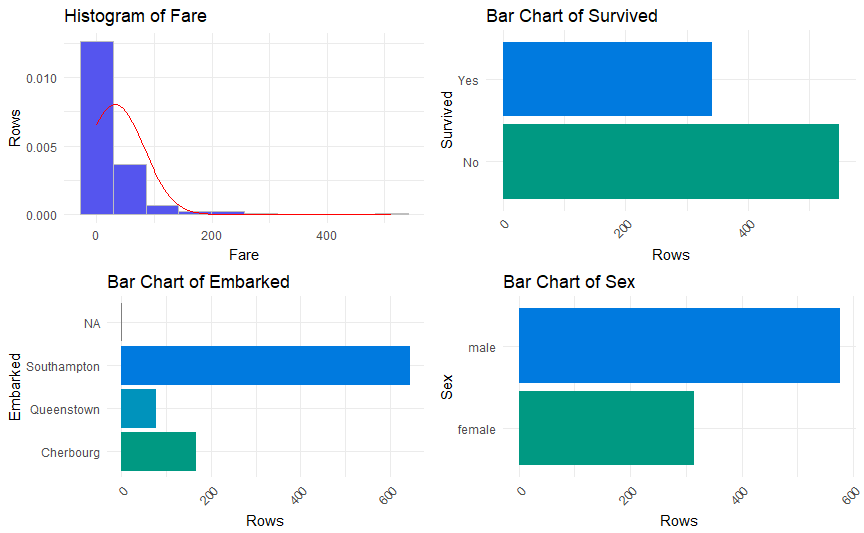

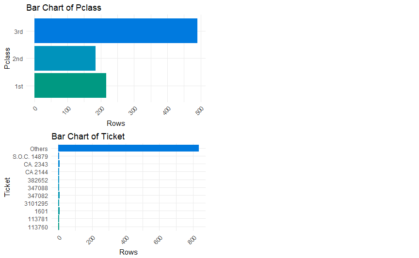

```r
training %>%
  select(-PassengerId, -Name) %>%
  mutate(Pclass = factor(Pclass, ordered = FALSE)) %>%
  xray::distributions()
```

The `distributions()` function gives us a very rough visual tool for inspecting the variables. The function allows us to see some general trends and places that could use further checking. For instance, with this data set, it is clear that the fare is being skewed by large outliers. Both the cabin and ticket variables have many categories with low counts that make them hard to visualize with a bar plot. However, the `distributions()` function works great for the other variables as a means of quick visual analysis.

### Thoughts on `xray` package

The functions in the `xray` package provide a simple way to quickly glean some insight from unknown data sets. By letting the user pull out information on the anomalies and distributions of variables, the user is able to easily compare the variables and determine which ones require further investigation. It is a wonderful stepping off point for deeper analysis and I look forward to see the package develop further.

## Further Exploration

The `xray` package has given us a good starting point for some further analysis. We will want to look closer at the Fare and Age variables as there might be further structure hidden due to the outliers and binning choices. We also want to inspect the Age variable for the NAs that are present and see if we can extract anything useful. We may also want to look at the Ticket variable and see if there is a good way to represent the tickets.

### Fare

If we remove all of the fares above 200 and increase the number of bins to 20, we start to see a more structured distribution. We still get a long tail out to large fares, but we now have a sharp spike at lower fare values with a small pedestal around 20 to 40.

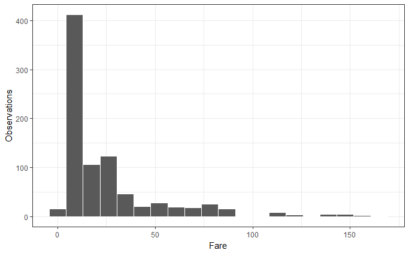

```r
training %>%
  filter(Fare <= 200) %>%
  ggplot(aes(x = Fare)) +
  geom_histogram(bins = 20, color = "white") +
  theme_bw() +
  labs(x = "Fare",
       y = "Observations")
```

### Age

We can examine the Age variable further by reproducing the Age histogram from `xray::distributions()`, but increasing the number of bins to 30. From that, we see that the ages are distributed with a slight skew to older ages. There is also a small drop off in younger passnegers from ages 6 to 14.

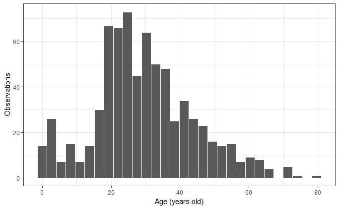

```r
training %>%
  filter(!is.na(Age)) %>%
  ggplot(aes(x = Age)) +
  geom_histogram(bins = 30, color = "white") +
  theme_bw() +
  labs(x = "Age (years old)",
       y = "Observations")
```

Next, we want to explore whether there is any connection between missing Age values and the other variables. Doing a quick visual exploration of the data, most of the missing Age values seem to also be missing Cabin values. Looking at the names, these appear to be passengers from various age ranges as some of the names are women with married names. To further examine, we can use the `xray::distributions()` function again on just the Ages with NA’s.

| Variable | p_1 | p_10 | p_25 | p_50 | p_75 | p_90 | p_99 |
| --- | --- | --- | --- | --- | --- | --- | --- |
| Parch | 0 | 0 | 0 | 0 | 0 | 1 | 2 |
| SibSp | 0 | 0 | 0 | 0 | 0 | 1 | 8 |
| Fare | 0 | 7.2292 | 7.75 | 8.05 | 24.15 | 55.5983 | 164.5828 |

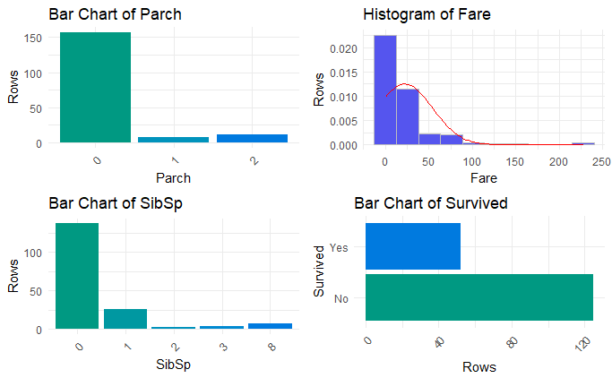

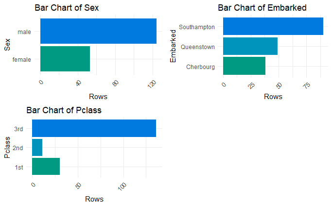

```r
training %>%
  filter(is.na(Age)) %>%
  mutate(Pclass = factor(Pclass, ordered = FALSE)) %>%
  select(-Age, -PassengerId, -Ticket, -Name, -Cabin) %>%
  xray::distributions()
```

From these figures, we can see that many of the Age NA’s come from lower class passengers and that a majority of them were male and did not survive. From this, I would say that the observations with Age NA’s cannot be ignored. To get around this for modeling, we could try binning the ages and including a bin that contains all the missing ages. According to the data explanation included with this data sets, these missing ages may be estimated ages that did not make it into the Kaggle dataset.

### Ticket

Lastly, I want to take a closer look at the tickets. According to the `xray::anamolies()` function, there are at least few non-unique tickets. Since there are a large number of categories with only a few counts in each, an easier way to model these may be to bin the tickets based on their uniqueness, i.e., is a particular ticket unique to 1 person, 2 people, 3 people, etc. We can examine this by grouping by the Ticket, getting the count per ticket, and then creating a contingency table of the number of counts.

```r
training %>%
  group_by(Ticket) %>%
  count() %>%
  ungroup() %>%
  select(-Ticket) %>%
  table()
```

```
.
  1   2   3   4   5   6   7
547  94  21  11   2   3   3
```

From the contingency table, we can see that the majority of the tickets are unique, with the next highest being unique to two people. For modeling, we will likely want to collapse 5, 6, and 7 down to a single category of 5+ due to the low counts in those categories.

## Next Steps

Now that we have taken a look at the data, we will next want to clean it and get it in a form that we can send to our models. This may include a few feature transformations as well. Of the cleaning we need to do, removing some of the NA’s we found will be the first step. Unfortunately, some of the variables have a large number of NA’s so we will need to transform those variables to account for them.

Some feature transformations that may be useful are splitting the names of passengers apart to get to their titles (Mr., Mrs., Doctor, etc.). Another transformation mentioned above would be to bin the ages, allowing for an “Unknown” bin to handle all the missing ages. The ticket information can also be transformed based on the number of passengers that used the same ticket.